# DADA2 sample processing for *A. cervicornis* microplastics project

Last run on 07 July 2022

I am largely following the [DADA2](https://www.bioconductor.org/packages/release/bioc/manuals/dada2/man/dada2.pdf) tutorial by Benjamin Callahan that can be found [here](https://benjjneb.github.io/dada2/tutorial.html).

## Inspecting the data

### Check samples to use

```
##  [1] "A1"  "A10" "A11" "A12" "A2"  "A3"  "A4"  "A5"  "A6"  "A7"  "A8"  "A9"
## [13] "B1"  "B10" "B11" "B12" "B2"  "B3"  "B4"  "B5"  "B6"  "B7"  "B8"  "B9"
## [25] "C1"  "C10" "C11" "C12" "C2"  "C3"  "C4"  "C5"  "C6"  "C7"  "C8"  "C9"
## [37] "G5"  "G6"
```

### View example quality plots

Viewing the quality of 2 of the forward samples

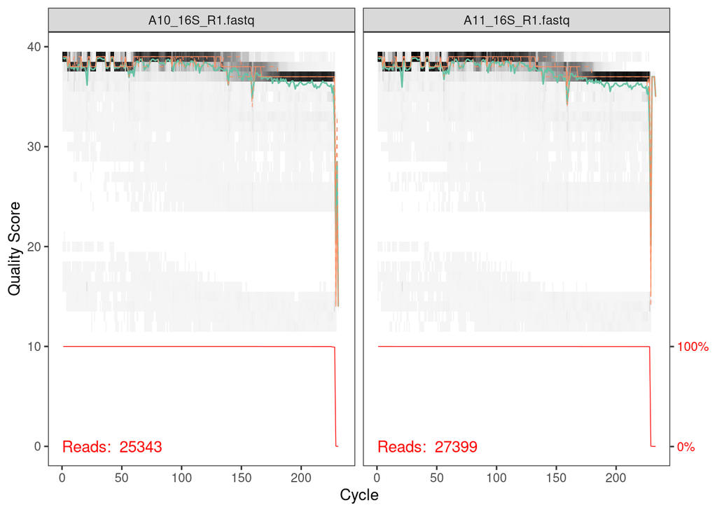

Viewing the quality of the same 2 of the reverse samples

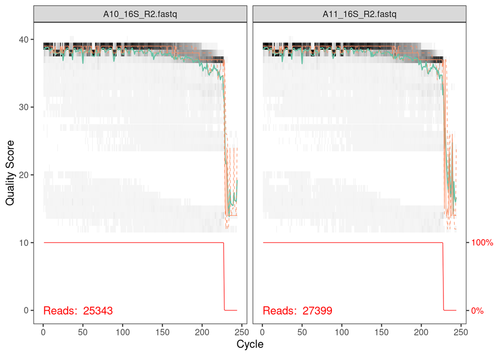

## Filter and trim samples

### Perform the filtering

```
##                  reads.in reads.out
## A1_16S_R1.fastq     46971     44462
## A10_16S_R1.fastq    25343     23991
## A11_16S_R1.fastq    27399     26007
## A12_16S_R1.fastq    45822     44152
## A2_16S_R1.fastq     99391     94837
## A3_16S_R1.fastq     77568     73176
```

```
## reads.out
## 0.9554531
```

### Check the filtering

Viewing the quality of the same 2 of the forward samples post filtering and trimming

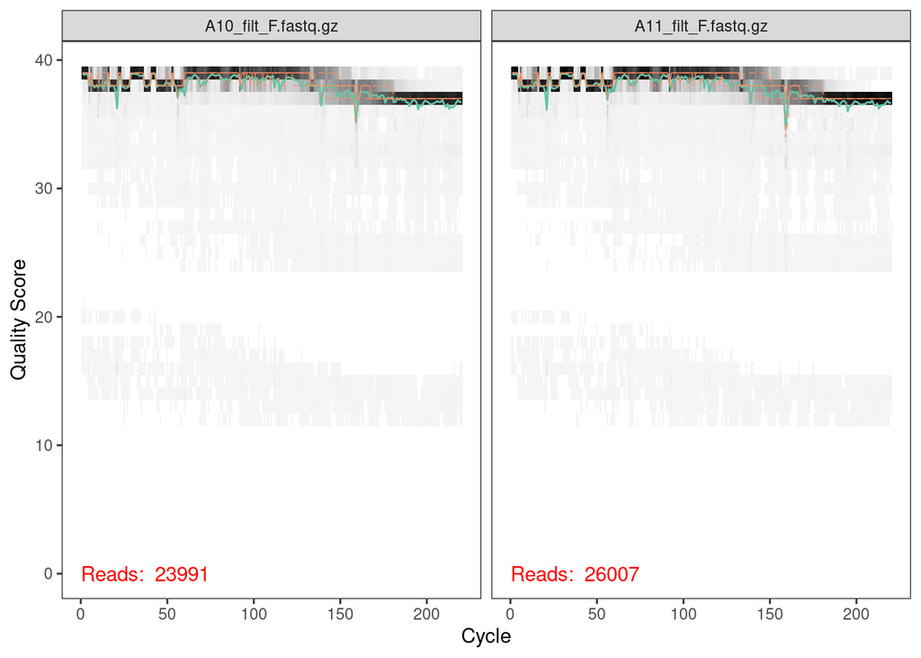

Viewing the quality of the same 2 of the reverse samples post filtering and trimming

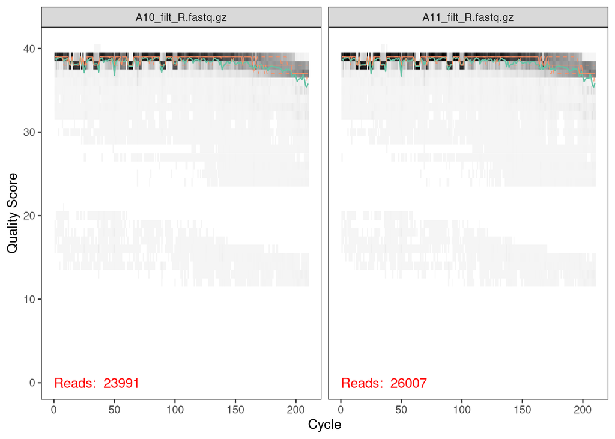

### Error Rates

```
## 102812380 total bases in 467329 reads from 10 samples will be used for learning the error rates.
```

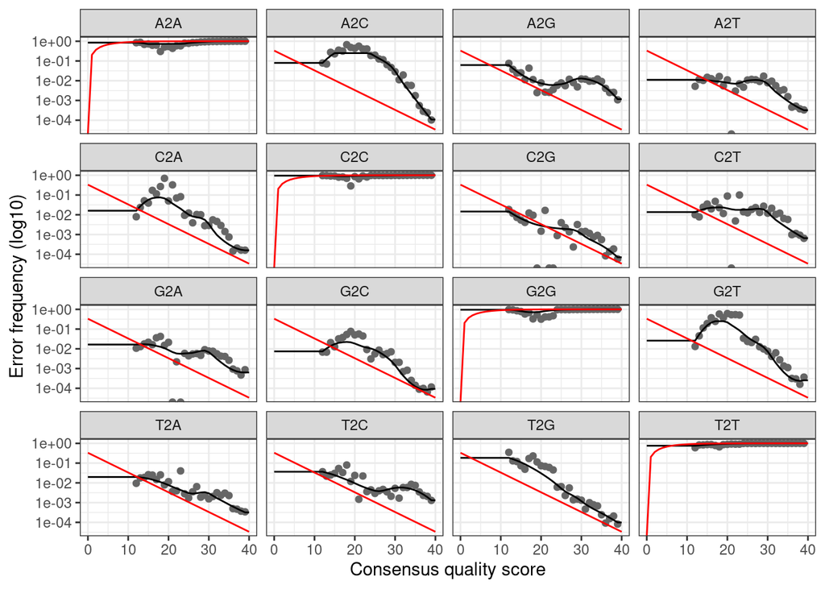

```
## 108324930 total bases in 515833 reads from 11 samples will be used for learning the error rates.
```

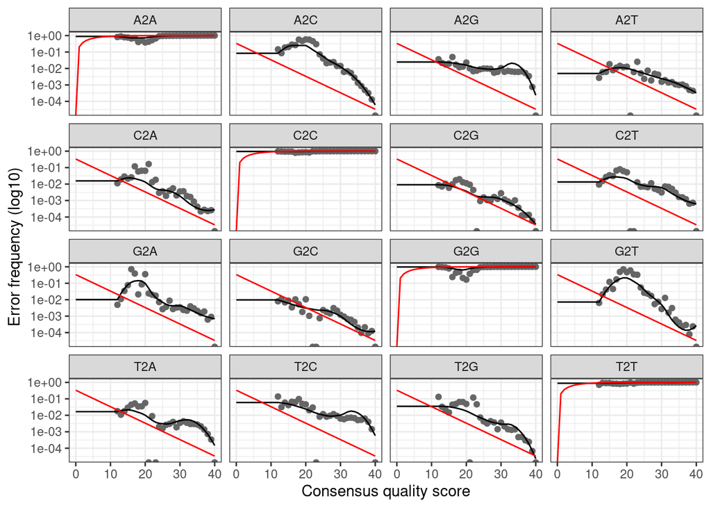

```
## Sample 1 - 44462 reads in 9516 unique sequences.
## Sample 2 - 23991 reads in 6094 unique sequences.
## Sample 3 - 26007 reads in 6313 unique sequences.
## Sample 4 - 44152 reads in 7218 unique sequences.
## Sample 5 - 94837 reads in 13510 unique sequences.
## Sample 6 - 73176 reads in 9646 unique sequences.
## Sample 7 - 22069 reads in 4917 unique sequences.
## Sample 8 - 76845 reads in 25272 unique sequences.
## Sample 9 - 41898 reads in 7510 unique sequences.
## Sample 10 - 19892 reads in 5018 unique sequences.
## Sample 11 - 48504 reads in 7342 unique sequences.
## Sample 12 - 32048 reads in 7630 unique sequences.
## Sample 13 - 90475 reads in 7748 unique sequences.
## Sample 14 - 24910 reads in 5725 unique sequences.
## Sample 15 - 34782 reads in 5737 unique sequences.
## Sample 16 - 50069 reads in 5167 unique sequences.
## Sample 17 - 76155 reads in 7895 unique sequences.
## Sample 18 - 34374 reads in 5211 unique sequences.
## Sample 19 - 90460 reads in 8319 unique sequences.
## Sample 20 - 23566 reads in 5815 unique sequences.
## Sample 21 - 53651 reads in 5991 unique sequences.
## Sample 22 - 110661 reads in 10439 unique sequences.
## Sample 23 - 14928 reads in 3601 unique sequences.
## Sample 24 - 30117 reads in 6469 unique sequences.
## Sample 25 - 27927 reads in 5388 unique sequences.
## Sample 26 - 73356 reads in 7647 unique sequences.
## Sample 27 - 23594 reads in 6498 unique sequences.
## Sample 28 - 20343 reads in 4504 unique sequences.
## Sample 29 - 25590 reads in 6768 unique sequences.
## Sample 30 - 10144 reads in 3129 unique sequences.
## Sample 31 - 42054 reads in 7901 unique sequences.
## Sample 32 - 25161 reads in 7367 unique sequences.
## Sample 33 - 73293 reads in 8481 unique sequences.
## Sample 34 - 37175 reads in 5029 unique sequences.
## Sample 35 - 30216 reads in 4299 unique sequences.
## Sample 36 - 43609 reads in 5217 unique sequences.
## Sample 37 - 1796 reads in 422 unique sequences.
## Sample 38 - 162 reads in 63 unique sequences.
```

```
## dada-class: object describing DADA2 denoising results
## 144 sequence variants were inferred from 9516 input unique sequences.
## Key parameters: OMEGA_A = 1e-40, OMEGA_C = 1e-40, BAND_SIZE = 16
```

```
## Sample 1 - 44462 reads in 9176 unique sequences.
## Sample 2 - 23991 reads in 5924 unique sequences.
## Sample 3 - 26007 reads in 6093 unique sequences.
## Sample 4 - 44152 reads in 7108 unique sequences.
## Sample 5 - 94837 reads in 12282 unique sequences.
## Sample 6 - 73176 reads in 8688 unique sequences.
## Sample 7 - 22069 reads in 4797 unique sequences.
## Sample 8 - 76845 reads in 24797 unique sequences.
## Sample 9 - 41898 reads in 7150 unique sequences.
## Sample 10 - 19892 reads in 4939 unique sequences.
## Sample 11 - 48504 reads in 7069 unique sequences.
## Sample 12 - 32048 reads in 7283 unique sequences.
## Sample 13 - 90475 reads in 7578 unique sequences.
## Sample 14 - 24910 reads in 5526 unique sequences.
## Sample 15 - 34782 reads in 5706 unique sequences.
## Sample 16 - 50069 reads in 5134 unique sequences.
## Sample 17 - 76155 reads in 7407 unique sequences.
## Sample 18 - 34374 reads in 4744 unique sequences.
## Sample 19 - 90460 reads in 8211 unique sequences.
## Sample 20 - 23566 reads in 5706 unique sequences.
## Sample 21 - 53651 reads in 5681 unique sequences.
## Sample 22 - 110661 reads in 10195 unique sequences.
## Sample 23 - 14928 reads in 3754 unique sequences.
## Sample 24 - 30117 reads in 6447 unique sequences.
## Sample 25 - 27927 reads in 5233 unique sequences.
## Sample 26 - 73356 reads in 7528 unique sequences.
## Sample 27 - 23594 reads in 6469 unique sequences.
## Sample 28 - 20343 reads in 4401 unique sequences.
## Sample 29 - 25590 reads in 6315 unique sequences.
## Sample 30 - 10144 reads in 3041 unique sequences.
## Sample 31 - 42054 reads in 7772 unique sequences.
## Sample 32 - 25161 reads in 7026 unique sequences.
## Sample 33 - 73293 reads in 8758 unique sequences.
## Sample 34 - 37175 reads in 5235 unique sequences.
## Sample 35 - 30216 reads in 4296 unique sequences.
## Sample 36 - 43609 reads in 5160 unique sequences.
## Sample 37 - 1796 reads in 466 unique sequences.
## Sample 38 - 162 reads in 69 unique sequences.
```

```
## dada-class: object describing DADA2 denoising results
## 142 sequence variants were inferred from 9176 input unique sequences.
## Key parameters: OMEGA_A = 1e-40, OMEGA_C = 1e-40, BAND_SIZE = 16
```

### Sample Inference

We are now ready to apply [the core sample inference algorithm](https://www.nature.com/articles/nmeth.3869#methods) to the filtered and trimmed sequence data.

```
## Sample 1 - 44462 reads in 9516 unique sequences.
## Sample 2 - 23991 reads in 6094 unique sequences.
## Sample 3 - 26007 reads in 6313 unique sequences.
## Sample 4 - 44152 reads in 7218 unique sequences.
## Sample 5 - 94837 reads in 13510 unique sequences.
## Sample 6 - 73176 reads in 9646 unique sequences.
## Sample 7 - 22069 reads in 4917 unique sequences.
## Sample 8 - 76845 reads in 25272 unique sequences.
## Sample 9 - 41898 reads in 7510 unique sequences.
## Sample 10 - 19892 reads in 5018 unique sequences.
## Sample 11 - 48504 reads in 7342 unique sequences.
## Sample 12 - 32048 reads in 7630 unique sequences.
## Sample 13 - 90475 reads in 7748 unique sequences.
## Sample 14 - 24910 reads in 5725 unique sequences.
## Sample 15 - 34782 reads in 5737 unique sequences.
## Sample 16 - 50069 reads in 5167 unique sequences.
## Sample 17 - 76155 reads in 7895 unique sequences.
## Sample 18 - 34374 reads in 5211 unique sequences.
## Sample 19 - 90460 reads in 8319 unique sequences.
## Sample 20 - 23566 reads in 5815 unique sequences.
## Sample 21 - 53651 reads in 5991 unique sequences.
## Sample 22 - 110661 reads in 10439 unique sequences.
## Sample 23 - 14928 reads in 3601 unique sequences.
## Sample 24 - 30117 reads in 6469 unique sequences.
## Sample 25 - 27927 reads in 5388 unique sequences.
## Sample 26 - 73356 reads in 7647 unique sequences.
## Sample 27 - 23594 reads in 6498 unique sequences.
## Sample 28 - 20343 reads in 4504 unique sequences.
## Sample 29 - 25590 reads in 6768 unique sequences.
## Sample 30 - 10144 reads in 3129 unique sequences.
## Sample 31 - 42054 reads in 7901 unique sequences.
## Sample 32 - 25161 reads in 7367 unique sequences.
## Sample 33 - 73293 reads in 8481 unique sequences.
## Sample 34 - 37175 reads in 5029 unique sequences.
## Sample 35 - 30216 reads in 4299 unique sequences.
## Sample 36 - 43609 reads in 5217 unique sequences.
## Sample 37 - 1796 reads in 422 unique sequences.
## Sample 38 - 162 reads in 63 unique sequences.
```

```
## Sample 1 - 44462 reads in 9176 unique sequences.
## Sample 2 - 23991 reads in 5924 unique sequences.
## Sample 3 - 26007 reads in 6093 unique sequences.
## Sample 4 - 44152 reads in 7108 unique sequences.
## Sample 5 - 94837 reads in 12282 unique sequences.
## Sample 6 - 73176 reads in 8688 unique sequences.
## Sample 7 - 22069 reads in 4797 unique sequences.
## Sample 8 - 76845 reads in 24797 unique sequences.
## Sample 9 - 41898 reads in 7150 unique sequences.
## Sample 10 - 19892 reads in 4939 unique sequences.
## Sample 11 - 48504 reads in 7069 unique sequences.
## Sample 12 - 32048 reads in 7283 unique sequences.
## Sample 13 - 90475 reads in 7578 unique sequences.
## Sample 14 - 24910 reads in 5526 unique sequences.
## Sample 15 - 34782 reads in 5706 unique sequences.
## Sample 16 - 50069 reads in 5134 unique sequences.
## Sample 17 - 76155 reads in 7407 unique sequences.
## Sample 18 - 34374 reads in 4744 unique sequences.
## Sample 19 - 90460 reads in 8211 unique sequences.
## Sample 20 - 23566 reads in 5706 unique sequences.
## Sample 21 - 53651 reads in 5681 unique sequences.
## Sample 22 - 110661 reads in 10195 unique sequences.
## Sample 23 - 14928 reads in 3754 unique sequences.
## Sample 24 - 30117 reads in 6447 unique sequences.
## Sample 25 - 27927 reads in 5233 unique sequences.
## Sample 26 - 73356 reads in 7528 unique sequences.
## Sample 27 - 23594 reads in 6469 unique sequences.
## Sample 28 - 20343 reads in 4401 unique sequences.
## Sample 29 - 25590 reads in 6315 unique sequences.
## Sample 30 - 10144 reads in 3041 unique sequences.
## Sample 31 - 42054 reads in 7772 unique sequences.
## Sample 32 - 25161 reads in 7026 unique sequences.
## Sample 33 - 73293 reads in 8758 unique sequences.
## Sample 34 - 37175 reads in 5235 unique sequences.
## Sample 35 - 30216 reads in 4296 unique sequences.
## Sample 36 - 43609 reads in 5160 unique sequences.
## Sample 37 - 1796 reads in 466 unique sequences.
## Sample 38 - 162 reads in 69 unique sequences.
```

```
## dada-class: object describing DADA2 denoising results
## 144 sequence variants were inferred from 9516 input unique sequences.
## Key parameters: OMEGA_A = 1e-40, OMEGA_C = 1e-40, BAND_SIZE = 16
```

### Merge paired reads

We now merge the forward and reverse reads together to obtain the full denoised sequences. Merging is performed by aligning the denoised forward reads with the reverse-complement of the corresponding denoised reverse reads, and then constructing the merged “contig” sequences. By default, merged sequences are only output if the forward and reverse reads overlap by at least 12 bases, and are identical to each other in the overlap region (but these conditions can be changed via function arguments).

```
##                                                                                                                                                                                                                                                        sequence
## 1 TACGAAGGGGGCAAGCGTTACTCGGAATTATTGGGCGTAAAGCGTGCGTAGGCGGTTTTA…
## 2 TACGAAGGGTGCAAGCGTTAATCGGAATTACTGGGCGTAAAGCGCGCGTAGGTGGTTCAG…
## 3 TACGTAGGGTGCAAGCGTTAATCGGAATTACTGGGCGTAAAGCGTGTGTAGGCGGTTCGG…
## 4 TACGGAGGGTGCAAGCGTTAATCGGAATTACTGGGCGTAAAGCGCACGCAGGCGGTTTGT…
## 5 GACGGAGGATGCAAGCGTTATCCGGAATTATTGGGCGTAAAGCGTCTGCAGGTGGCCATA…
## 6 TACGTAGGGTGCAAGCGTTAATCGGAATTACTGGGCGTAAAGCGTGCGCAGGCGGTTCGG…
##   abundance forward reverse nmatch nmismatch nindel prefer accept
## 1     27348       1       1    177         0      0      1   TRUE
## 2      2081       2       2    177         0      0      2   TRUE
## 3      1589       3       3    177         0      0      2   TRUE
## 4       841       4       4    177         0      0      2   TRUE
## 5       553       5       5    177         0      0      2   TRUE
## 6       504       6       6    177         0      0      2   TRUE
```

The mergers object is a list of data.frames from each sample. Each data.frame contains the merged sequence, its abundance, and the indices of the forward and reverse sequence variants that were merged. Paired reads that did not exactly overlap were removed by mergePairs, further reducing spurious output.

### Construct sequence table

We can now construct an amplicon sequence variant table (ASV) table, a higher-resolution version of the OTU table produced by traditional methods.

```
## [1]   38 3546
```

```
##
##  221  222  223  227  228  239  246  249  250  251  252  253  254  255  256  257
##    1    2    4    4    1    1    1    1    1   10  105 3259  140    9    5    2
```

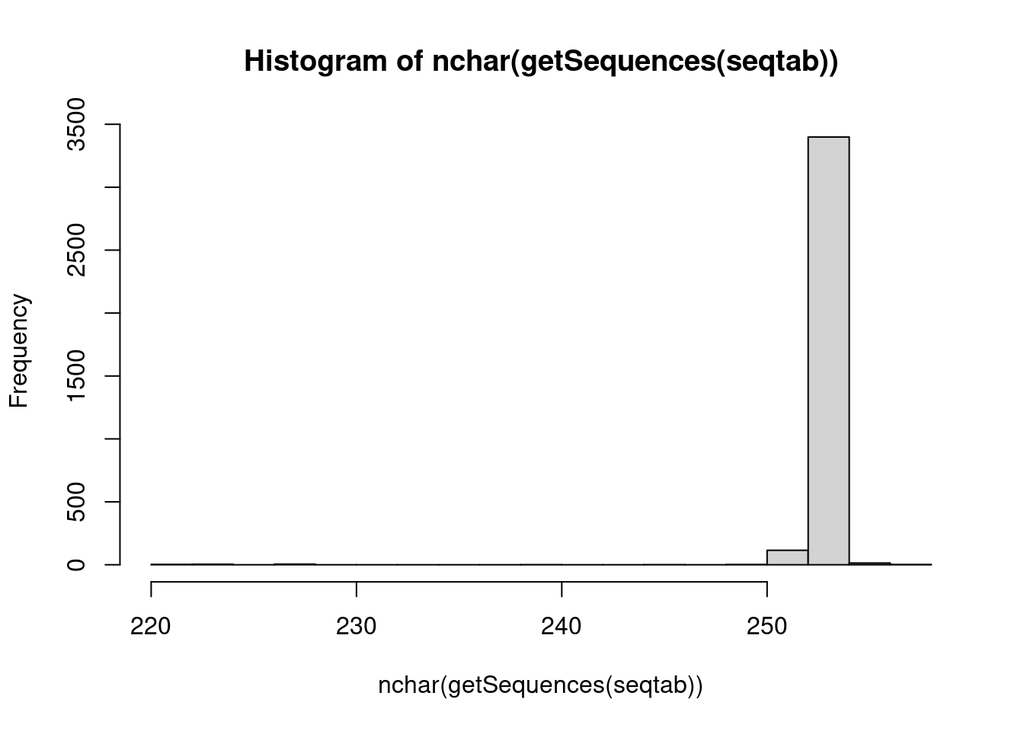

```
##
##  250  251  252  253  254  255
##    1   10  105 3259  140    9
```

The sequence table is a matrix with rows corresponding to (and named by) the samples, and columns corresponding to (and named by) the sequence variants. This table contains 3546 ASVs.

### Remove chimeras

The core dada method corrects substitution and indel errors, but chimeras remain. Fortunately, the accuracy of sequence variants after denoising makes identifying chimeric ASVs simpler than when dealing with fuzzy OTUs. Chimeric sequences are identified if they can be exactly reconstructed by combining a left-segment and a right-segment from two more abundant “parent” sequences.

```
## [1]   38 3506
```

```
## [1] 0.9989077
```

### Track reads through the pipeline

As a final check of our progress, we’ll look at the number of reads that made it through each step in the pipeline:

```
##      input filtered denoisedF denoisedR merged nonchim
## A1   46971    44462     44392     44369  44242   44242
## A10  25343    23991     23882     23969  23811   23811
## A11  27399    26007     25982     25986  25976   25976
## A12  45822    44152     44099     44109  43973   43973
## A2   99391    94837     94653     94671  94353   94205
## A3   77568    73176     73129     73130  73019   73019
## A4   23219    22069     22048     22045  22026   22026
## A5   82625    76845     76349     76439  73826   72577
## A6   44720    41898     41807     41866  41495   41495
## A7   21017    19892     19813     19857  19742   19742
## A8   50868    48504     48363     48414  48090   48085
## A9   33630    32048     31998     31994  31891   31891
## B1   93788    90475     90409     90402  90155   90155
## B10  26111    24910     24846     24859  24708   24683
## B11  36049    34782     34765     34754  34710   34666
## B12  51803    50069     49983     50014  49874   49845
## B2   79689    76155     76112     76109  75821   75792
## B3   36469    34374     34349     34353  34289   34289
## B4   93851    90460     90421     90323  90201   90201
## B5   24767    23566     23506     23538  23364   23328
## B6   56820    53651     53600     53596  53342   53342
## B7  114867   110661    110347    110599 110242  110229
## B8   16088    14928     14822     14864  14767   14717
## B9   31587    30117     30045     30016  29943   29901
## C1   29051    27927     27900     27896  27851   27851
## C10  75311    73356     73247     73255  72971   72971
## C11  24572    23594     23583     23578  23571   23571
## C12  21209    20343     20305     20329  20214   20214
## C2   26776    25590     25551     25561  25491   25491
## C3   10752    10144     10095     10134  10026   10026
## C4   43599    42054     42021     42021  41807   41723
## C5   26544    25161     25122     25096  25002   25002
## C6   76574    73293     73263     73255  72994   72994
## C7   38503    37175     37138     37084  36876   36876
## C8   31488    30216     30071     30045  29692   29692
## C9   44886    43609     43583     43597  43543   43543
## G5    1918     1796      1792      1792   1792    1792
## G6     169      162       153       158    153     153
```

Looks good! We kept the majority of our raw reads, and there is no over-large drop associated with any single step.

### Assign taxonomy

It is common at this point, especially in 16S/18S/ITS amplicon sequencing, to assign taxonomy to the sequence variants. The DADA2 package provides a native implementation of the naive Bayesian classifier method for this purpose. The `assignTaxonomy` function takes as input a set of sequences to be classified and a training set of reference sequences with known taxonomy, and outputs taxonomic assignments with at least `minBoot` bootstrap confidence.

We maintain formatted training fastas for the RDP training set, GreenGenes clustered at 97% identity, and the Silva reference database, and additional trainings fastas suitable for protists and certain specific environments have been contributed. For fungal taxonomy, the General Fasta release files from the UNITE ITS database can be used as is. To follow along, download the silva_nr99_v138.1_train_set.fa.gz file, and place it in the directory with the fastq files.

The dada2 package GitHub maintains the most updated versions of the [Silva databases.](https://benjjneb.github.io/dada2/training.html). The versions in this GitHub repository, used here, were last updated on March 10, 2021.

Let’s inspect the taxonomic assignments:

```
##      Kingdom    Phylum             Class                 Order
## [1,] "Bacteria" "Proteobacteria"   "Alphaproteobacteria" "Rickettsiales"
## [2,] "Bacteria" "Proteobacteria"   "Gammaproteobacteria" "Pseudomonadales"
## [3,] "Bacteria" "Cyanobacteria"    "Cyanobacteriia"      "Chloroplast"
## [4,] "Bacteria" "Myxococcota"      "Myxococcia"          "Myxococcales"
## [5,] "Bacteria" "Proteobacteria"   "Gammaproteobacteria" "Burkholderiales"
## [6,] "Bacteria" "Campylobacterota" "Campylobacteria"     "Campylobacterales"
##      Family             Genus         Species
## [1,] "Fokiniaceae"      "MD3-55"      NA
## [2,] "Pseudomonadaceae" "Pseudomonas" NA
## [3,] NA                 NA            NA
## [4,] "Myxococcaceae"    "P3OB-42"     NA
## [5,] "Alcaligenaceae"   "Alcaligenes" NA
## [6,] NA                 NA            NA
```

**Considerations for your own data:** If your reads do not seem to be appropriately assigned, for example lots of your bacterial 16S sequences are being assigned as Eukaryota NA NA NA NA NA, your reads may be in the opposite orientation as the reference database. Tell dada2 to try the reverse-complement orientation with assignTaxonomy(…, tryRC=TRUE) and see if this fixes the assignments. If using DECIPHER for taxonomy, try IdTaxa (…, strand=“both”).

## Phyloseq pipeline

We can construct a simple sample data.frame from the information encoded in the filenames. Usually this step would instead involve reading the sample data in from a file.

```
##   sampleID Tank.. Genotype   Treatment
## 1       A1      1  15E - 1     AMB MP+
## 2       A2      2 10aA - 1     OAW MP+
## 3       A3      3  5aC - 2 AMB Control
## 4       A4      4  15E - 2 OAW Control
## 5       A5      5  15C - 1     OAW MP+
## 6       A6      6 10aB - 1     AMB MP+
```

We now construct a phyloseq object directly from the dada2 outputs.

```
## phyloseq-class experiment-level object
## otu_table()   OTU Table:         [ 3506 taxa and 38 samples ]
## sample_data() Sample Data:       [ 38 samples by 2 sample variables ]
## tax_table()   Taxonomy Table:    [ 3506 taxa by 6 taxonomic ranks ]
## refseq()      DNAStringSet:      [ 3506 reference sequences ]
```

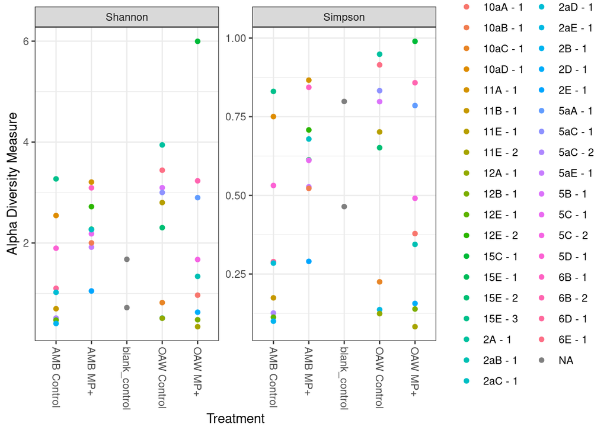

```
## *** Solution reached
```

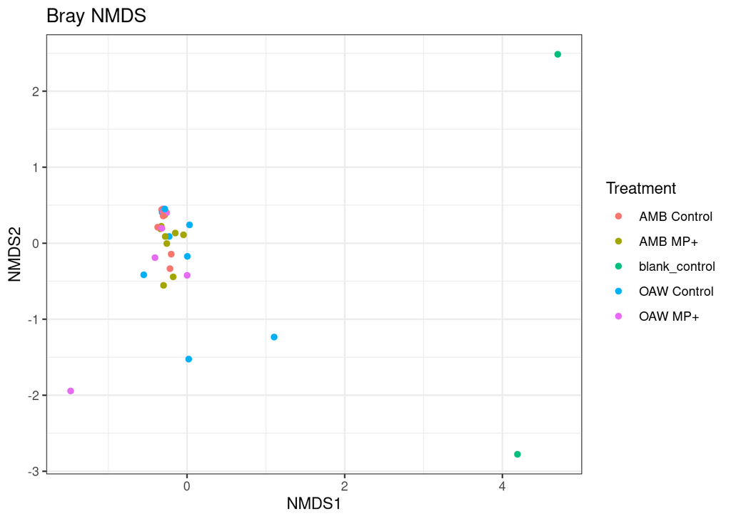

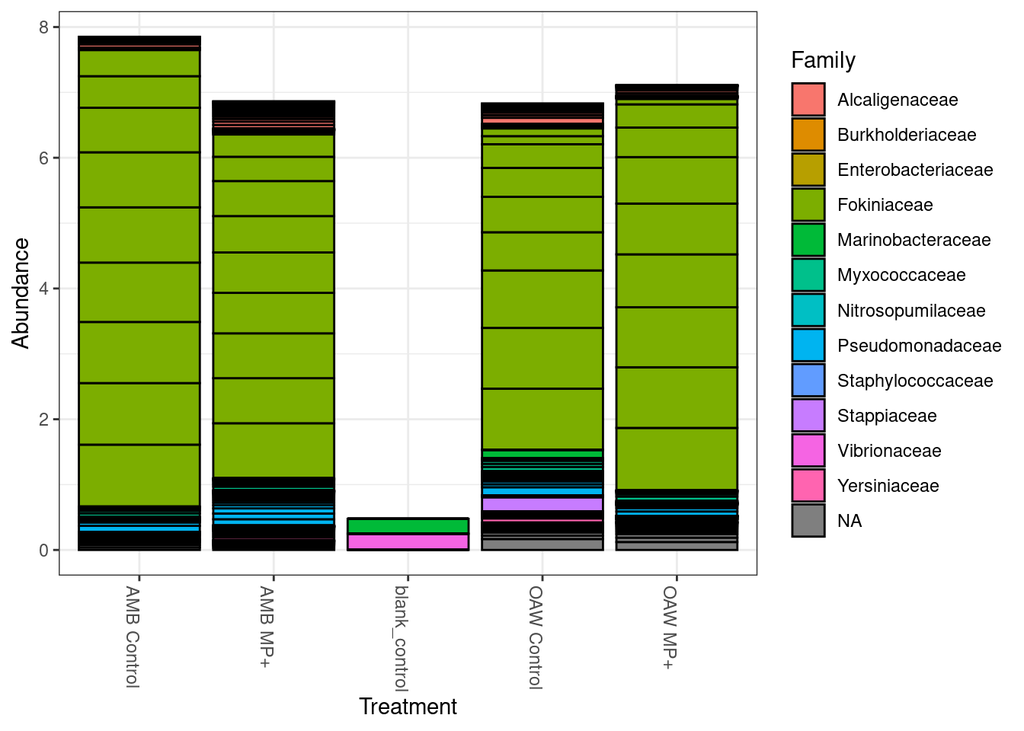

All code was written by [Colleen B. Bove](https://colleenbove.science), feel free to contact with questions.